# R Programming week 2 Unsupervised learning

Kevin Kilonzo

29/01/2022

## DEFINING THE QUESTION

### a) Specifying the question

Perform machine learning on the dataset below

### b) Defining the metric of success

To perform machine learning on the dataset below

### c) Understanding the context

Kira Plastinina is a Russian brand that is sold through a defunct chain of retail stores in Russia, Ukraine, Kazakhstan, Belarus, China, Philippines, and Armenia. The brand’s Sales and Marketing team would like to understand their customer’s behavior from data that they have collected over the past year. More specifically, they would like to learn the characteristics of customer groups. ### d) Recoding the experimental design 1. Defining the question 2. Instaling and loading the libraries 3. Loading the dataset 4. Cleaning the dataset 5. Performing univariate analysis 6. Performing bivariate analysis 7. Performing unsupervised learning 8. Performing Supervised Learning

### e) Data relevance

The dataset consists of 10 numerical and 8 categorical attributes. The ‘Revenue’ attribute can be used as the class label. * “Administrative”, “Administrative Duration”, “Informational”, “Informational Duration”, “Product Related” and “Product Related Duration” represents the number of different types of pages visited by the visitor in that session and total time spent in each of these page categories. The values of these features are derived from the URL information of the pages visited by the user and updated in real-time when a user takes an action, e.g. moving from one page to another. * The “Bounce Rate”, “Exit Rate” and “Page Value” features represent the metrics measured by “Google Analytics” for each page in the e-commerce site. The value of the “Bounce Rate” feature for a web page refers to the percentage of visitors who enter the site from that page and then leave (“bounce”) without triggering any other requests to the analytics server during that session. The value of the “Exit Rate” feature for a specific web page is calculated as for all pageviews to the page, the percentage that was the last in the session. The “Page Value” feature represents the average value for a web page that a user visited before completing an e-commerce transaction. *The “Special Day” feature indicates the closeness of the site visiting time to a specific special day (e.g. Mother’s Day, Valentine’s Day) in which the sessions are more likely to be finalized with the transaction. The value of this attribute is determined by considering the dynamics of e-commerce such as the duration between the order date and delivery date. For example, for Valentina’s day, this value takes a nonzero value between February 2 and February 12, zero before and after this date unless it is close to another special day, and its maximum value of 1 on February 8.* The dataset also includes the operating system, browser, region, traffic type, visitor type as returning or new visitor, a Boolean value indicating whether the date of the visit is weekend, and month of the year.

## LOADING PACKAGES

```r
library("data.table") # loads and manipulates the database
library(tidyverse) # loads and manipulates the database but with better visualisations
library(dbscan) # performs density based clustering in unsupervised learning
```

## LOADing AND CHECKING THE DATASET

```r
df <- fread("http://bit.ly/EcommerceCustomersDataset")

# Preview of the dataset
## First 6 records
head(df)
```

```
##    Administrative Administrative_Duration Informational Informational_Duration
## 1:              0                       0             0                      0
## 2:              0                       0             0                      0
## 3:              0                      -1             0                     -1
## 4:              0                       0             0                      0
## 5:              0                       0             0                      0
## 6:              0                       0             0                      0
##    ProductRelated ProductRelated_Duration BounceRates ExitRates PageValues
## 1:              1                0.000000  0.20000000 0.2000000          0
## 2:              2               64.000000  0.00000000 0.1000000          0
## 3:              1               -1.000000  0.20000000 0.2000000          0
## 4:              2                2.666667  0.05000000 0.1400000          0
## 5:             10              627.500000  0.02000000 0.0500000          0
## 6:             19              154.216667  0.01578947 0.0245614          0
##    SpecialDay Month OperatingSystems Browser Region TrafficType
## 1:          0   Feb                1       1      1           1
## 2:          0   Feb                2       2      1           2
## 3:          0   Feb                4       1      9           3
## 4:          0   Feb                3       2      2           4
## 5:          0   Feb                3       3      1           4
## 6:          0   Feb                2       2      1           3
##          VisitorType Weekend Revenue
## 1: Returning_Visitor   FALSE   FALSE
## 2: Returning_Visitor   FALSE   FALSE
## 3: Returning_Visitor   FALSE   FALSE
## 4: Returning_Visitor   FALSE   FALSE
## 5: Returning_Visitor    TRUE   FALSE
## 6: Returning_Visitor   FALSE   FALSE
```

```r
## Last 6 records
tail(df)
```

```
##    Administrative Administrative_Duration Informational Informational_Duration
## 1:              0                       0             1                      0
## 2:              3                     145             0                      0
## 3:              0                       0             0                      0
## 4:              0                       0             0                      0
## 5:              4                      75             0                      0
## 6:              0                       0             0                      0
##    ProductRelated ProductRelated_Duration BounceRates  ExitRates PageValues
## 1:             16                 503.000 0.000000000 0.03764706    0.00000
## 2:             53                1783.792 0.007142857 0.02903061   12.24172
## 3:              5                 465.750 0.000000000 0.02133333    0.00000
## 4:              6                 184.250 0.083333333 0.08666667    0.00000
## 5:             15                 346.000 0.000000000 0.02105263    0.00000
## 6:              3                  21.250 0.000000000 0.06666667    0.00000
##    SpecialDay Month OperatingSystems Browser Region TrafficType
## 1:          0   Nov                2       2      1           1
## 2:          0   Dec                4       6      1           1
## 3:          0   Nov                3       2      1           8
## 4:          0   Nov                3       2      1          13
## 5:          0   Nov                2       2      3          11
## 6:          0   Nov                3       2      1           2
##          VisitorType Weekend Revenue
## 1: Returning_Visitor   FALSE   FALSE
## 2: Returning_Visitor    TRUE   FALSE
## 3: Returning_Visitor    TRUE   FALSE
## 4: Returning_Visitor    TRUE   FALSE
## 5: Returning_Visitor   FALSE   FALSE
## 6:       New_Visitor    TRUE   FALSE
```

```r
# Showing the complete dataframe
view(df)
```

```r
# Check the number of rows and columns
dim(df) # rows  then  columns
```

```
## [1] 12330    18
```

```r
# Check the data types of the columns
str(df)
```

```
## Classes 'data.table' and 'data.frame':   12330 obs. of  18 variables:
##  $ Administrative         : int  0 0 0 0 0 0 0 1 0 0 ...
##  $ Administrative_Duration: num  0 0 -1 0 0 0 -1 -1 0 0 ...
##  $ Informational          : int  0 0 0 0 0 0 0 0 0 0 ...
##  $ Informational_Duration : num  0 0 -1 0 0 0 -1 -1 0 0 ...
##  $ ProductRelated         : int  1 2 1 2 10 19 1 1 2 3 ...
##  $ ProductRelated_Duration: num  0 64 -1 2.67 627.5 ...
##  $ BounceRates            : num  0.2 0 0.2 0.05 0.02 ...
##  $ ExitRates              : num  0.2 0.1 0.2 0.14 0.05 ...
##  $ PageValues             : num  0 0 0 0 0 0 0 0 0 0 ...
##  $ SpecialDay             : num  0 0 0 0 0 0 0.4 0 0.8 0.4 ...
##  $ Month                  : chr  "Feb" "Feb" "Feb" "Feb" ...
##  $ OperatingSystems       : int  1 2 4 3 3 2 2 1 2 2 ...
##  $ Browser                : int  1 2 1 2 3 2 4 2 2 4 ...
##  $ Region                 : int  1 1 9 2 1 1 3 1 2 1 ...
##  $ TrafficType            : int  1 2 3 4 4 3 3 5 3 2 ...
##  $ VisitorType            : chr  "Returning_Visitor" "Returning_Visitor" "Returning_Visitor" "Returning_Visitor" ...
##  $ Weekend                : logi  FALSE FALSE FALSE FALSE TRUE FALSE ...
##  $ Revenue                : logi  FALSE FALSE FALSE FALSE FALSE FALSE ...
##  - attr(*, ".internal.selfref")=<externalptr>
```

```r
# Checking column names
colnames(df)
```

```
##  [1] "Administrative"          "Administrative_Duration"
##  [3] "Informational"           "Informational_Duration"
##  [5] "ProductRelated"          "ProductRelated_Duration"
##  [7] "BounceRates"             "ExitRates"
##  [9] "PageValues"              "SpecialDay"
## [11] "Month"                   "OperatingSystems"
## [13] "Browser"                 "Region"
## [15] "TrafficType"             "VisitorType"
## [17] "Weekend"                 "Revenue"
```

## CLEANING THE DATASET

```r
# Getting statistical summary of the data
summary(df)
```

```
##  Administrative   Administrative_Duration Informational
##  Min.   : 0.000   Min.   :  -1.00         Min.   : 0.000
##  1st Qu.: 0.000   1st Qu.:   0.00         1st Qu.: 0.000
##  Median : 1.000   Median :   8.00         Median : 0.000
##  Mean   : 2.318   Mean   :  80.91         Mean   : 0.504
##  3rd Qu.: 4.000   3rd Qu.:  93.50         3rd Qu.: 0.000
##  Max.   :27.000   Max.   :3398.75         Max.   :24.000
##  NA's   :14       NA's   :14              NA's   :14
##  Informational_Duration ProductRelated   ProductRelated_Duration
##  Min.   :  -1.00        Min.   :  0.00   Min.   :   -1.0
##  1st Qu.:   0.00        1st Qu.:  7.00   1st Qu.:  185.0
##  Median :   0.00        Median : 18.00   Median :  599.8
##  Mean   :  34.51        Mean   : 31.76   Mean   : 1196.0
##  3rd Qu.:   0.00        3rd Qu.: 38.00   3rd Qu.: 1466.5
##  Max.   :2549.38        Max.   :705.00   Max.   :63973.5
##  NA's   :14             NA's   :14       NA's   :14
##   BounceRates         ExitRates         PageValues        SpecialDay
##  Min.   :0.000000   Min.   :0.00000   Min.   :  0.000   Min.   :0.00000
##  1st Qu.:0.000000   1st Qu.:0.01429   1st Qu.:  0.000   1st Qu.:0.00000
##  Median :0.003119   Median :0.02512   Median :  0.000   Median :0.00000
##  Mean   :0.022152   Mean   :0.04300   Mean   :  5.889   Mean   :0.06143
##  3rd Qu.:0.016684   3rd Qu.:0.05000   3rd Qu.:  0.000   3rd Qu.:0.00000
##  Max.   :0.200000   Max.   :0.20000   Max.   :361.764   Max.   :1.00000
##  NA's   :14         NA's   :14
##     Month           OperatingSystems    Browser           Region
##  Length:12330       Min.   :1.000    Min.   : 1.000   Min.   :1.000
##  Class :character   1st Qu.:2.000    1st Qu.: 2.000   1st Qu.:1.000
##  Mode  :character   Median :2.000    Median : 2.000   Median :3.000
##                     Mean   :2.124    Mean   : 2.357   Mean   :3.147
##                     3rd Qu.:3.000    3rd Qu.: 2.000   3rd Qu.:4.000
##                     Max.   :8.000    Max.   :13.000   Max.   :9.000
##
##   TrafficType    VisitorType         Weekend         Revenue
##  Min.   : 1.00   Length:12330       Mode :logical   Mode :logical
##  1st Qu.: 2.00   Class :character   FALSE:9462      FALSE:10422
##  Median : 2.00   Mode  :character   TRUE :2868      TRUE :1908
##  Mean   : 4.07
##  3rd Qu.: 4.00
##  Max.   :20.00
##
```

```r
#Convert column names to lowercase
names(df) <- tolower(colnames(df))

# Checking null values
colSums(is.na(df))
```

```
##          administrative administrative_duration           informational
##                      14                      14                      14
##  informational_duration          productrelated productrelated_duration
##                      14                      14                      14
##             bouncerates               exitrates              pagevalues
##                      14                      14                       0
##              specialday                   month        operatingsystems
##                       0                       0                       0
##                 browser                  region             traffictype
##                       0                       0                       0
##             visitortype                 weekend                 revenue
##                       0                       0                       0
```

```r
## drop missing values since they represent less than 10 % of the data
df <- na.omit(df)

# Checking for duplicates
df[duplicated(df),]
```

```
##      administrative administrative_duration informational
##   1:              0                       0             0
##   2:              0                       0             0
##   3:              0                       0             0
##   4:              0                       0             0
##   5:              0                       0             0
##  ---
## 113:              0                       0             0
## 114:              0                       0             0
## 115:              0                       0             0
## 116:              0                       0             0
## 117:              0                       0             0
##      informational_duration productrelated productrelated_duration bouncerates
##   1:                      0              1                       0         0.2
##   2:                      0              1                       0         0.2
```

[output cut: 33 more lines]

```r
## drop duplicates since they are less than 10% of data
df <- unique(df)

# Convert months to numerical
df$month <-match(df$month,month.abb)
df$month <- as.integer(df$month)
#convert logical columns to numeric
df$weekend <- as.integer(df$weekend)
df$revenue <- as.integer(df$revenue)
```

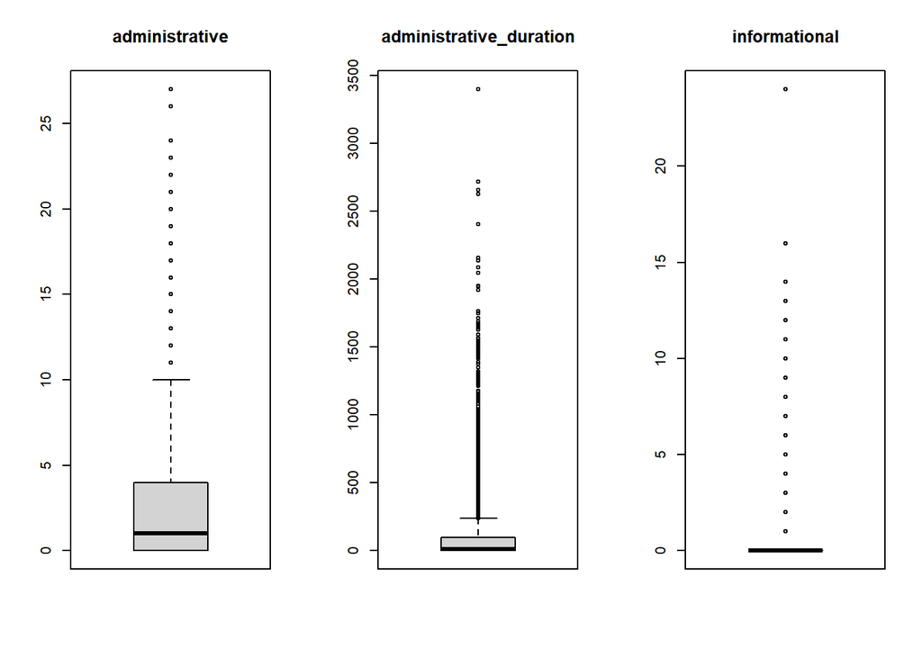

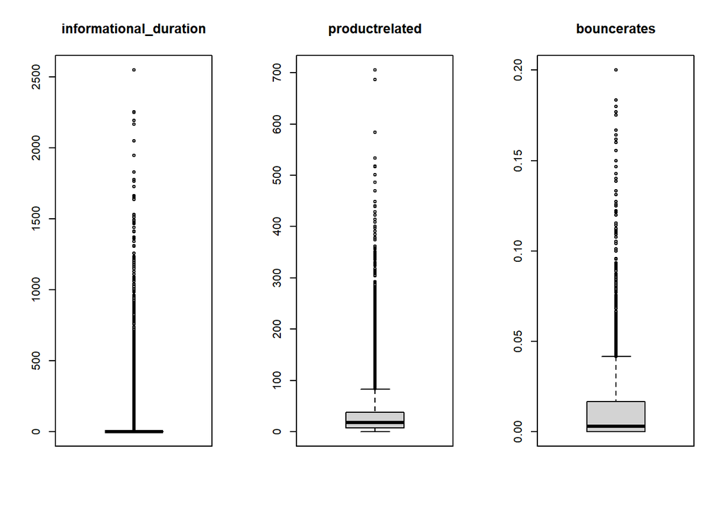

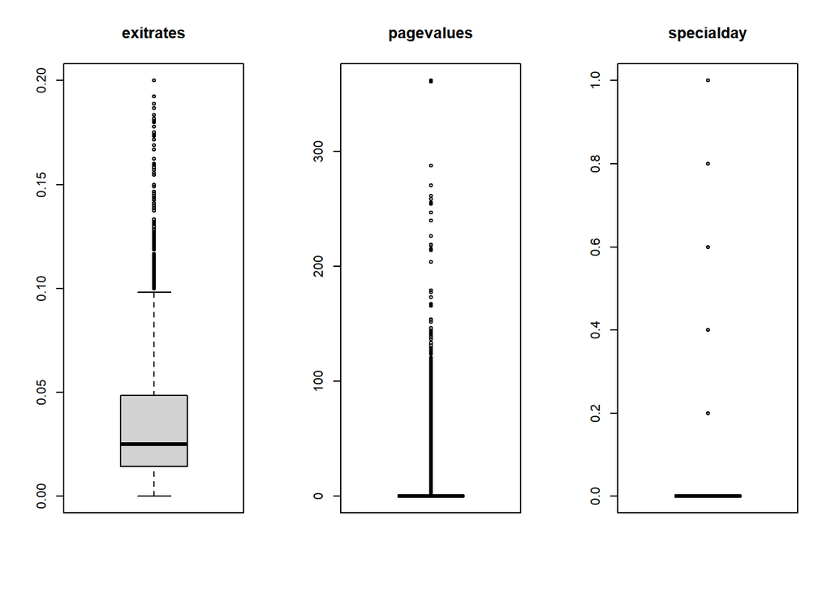

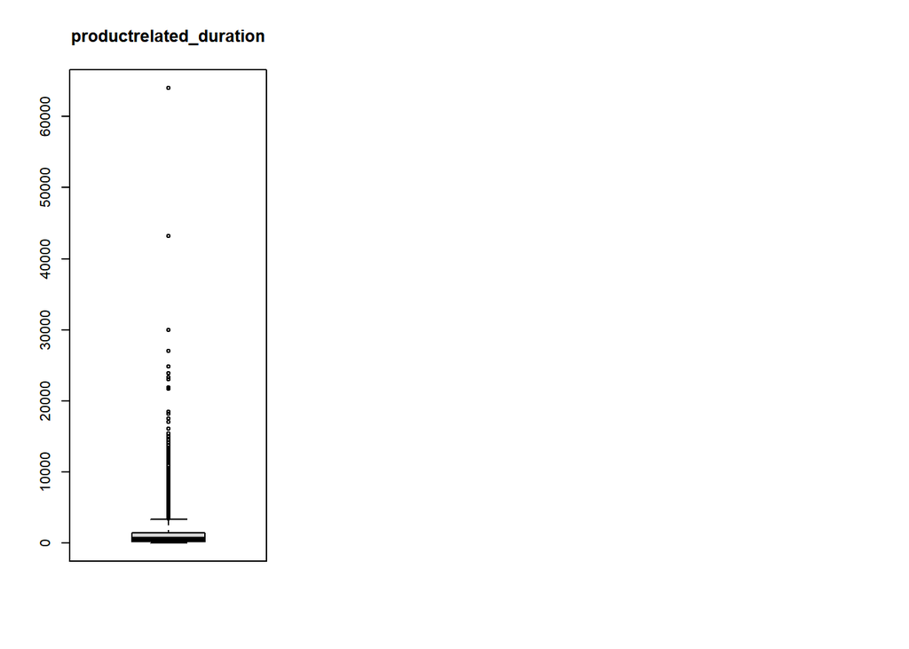

```r
# Checking for outliers
## getting the numeric columns
contvar <- df %>% select(administrative,administrative_duration,informational,informational_duration,productrelated,bouncerates,     exitrates,pagevalues,specialday,productrelated_duration)
par(mfrow = c(1,3))
invisible(lapply(1:ncol(contvar), function(i) boxplot(contvar[,..i], main = paste(colnames(contvar[,..i])))))
```

The outliers are expected in such a dataset and will not be removed ## UNIVARIATE ANALYSIS

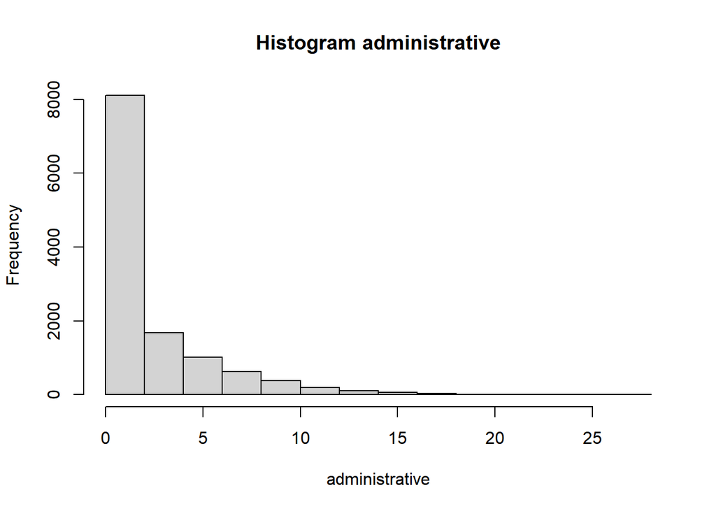

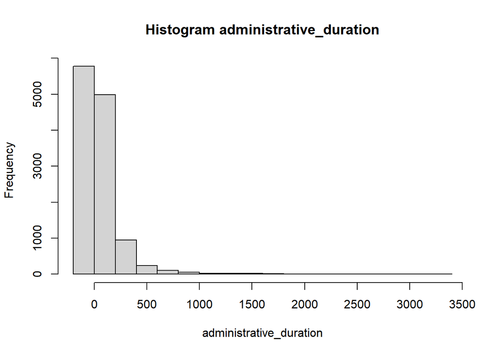

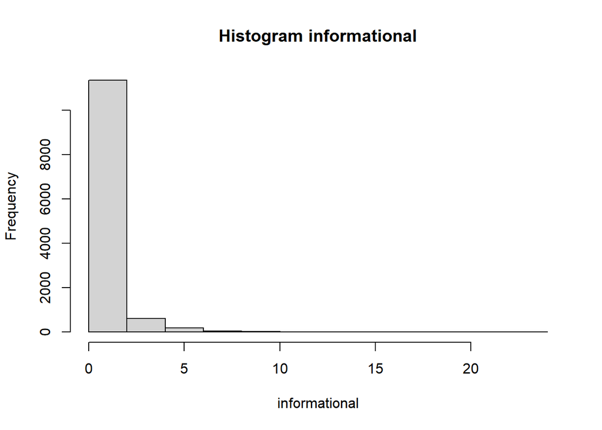

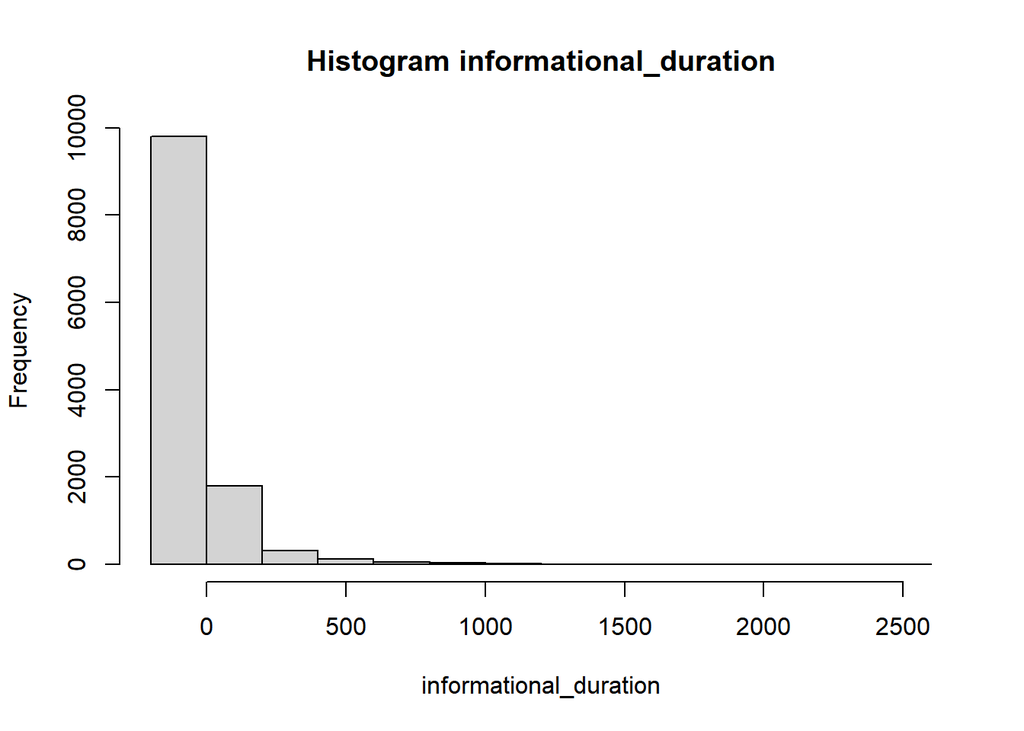

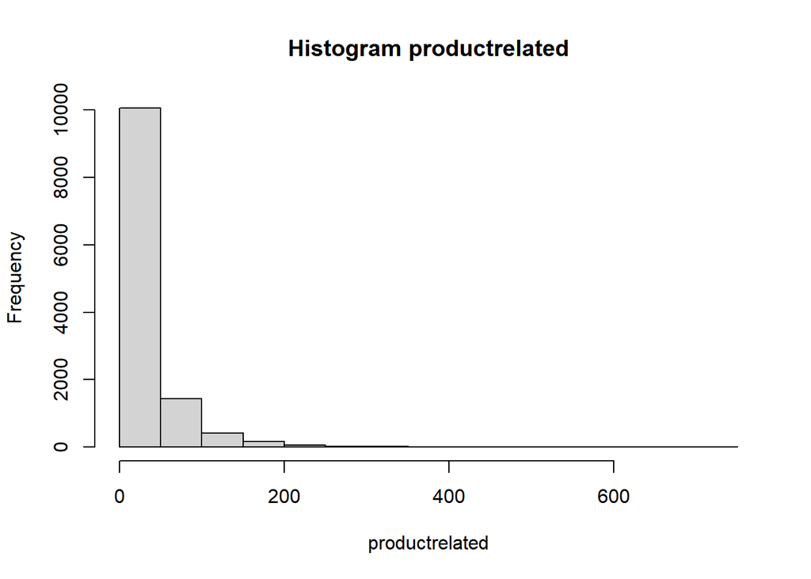

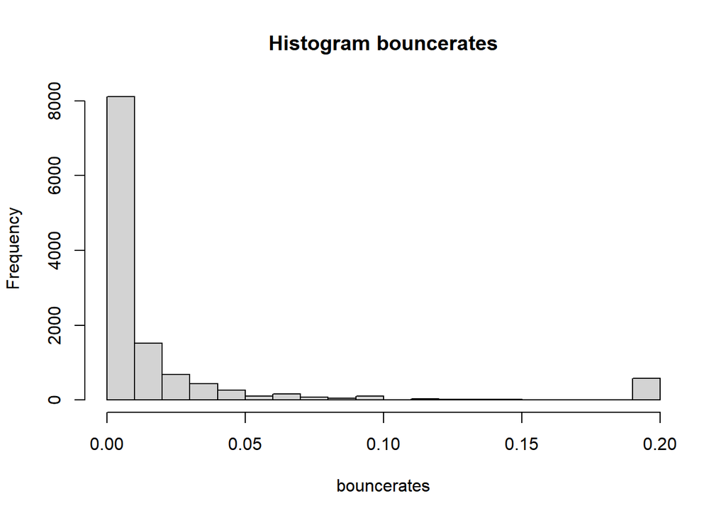

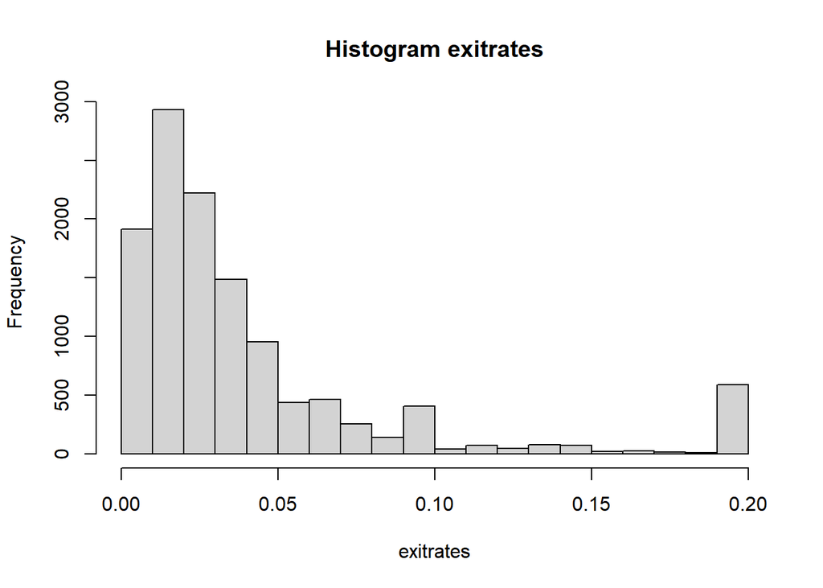

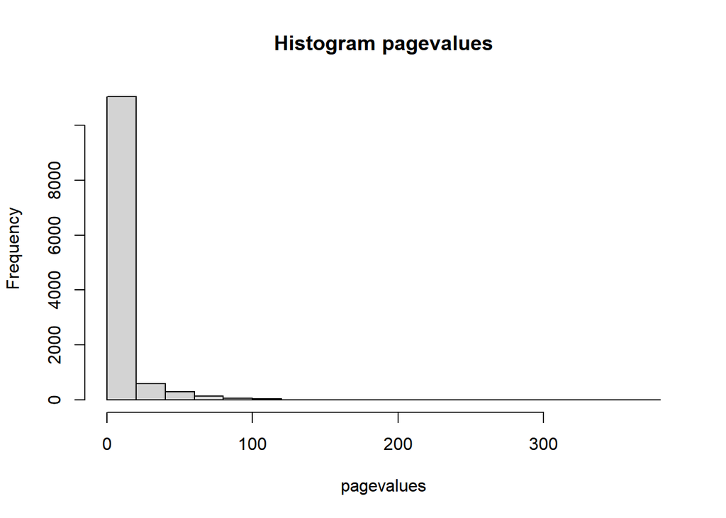

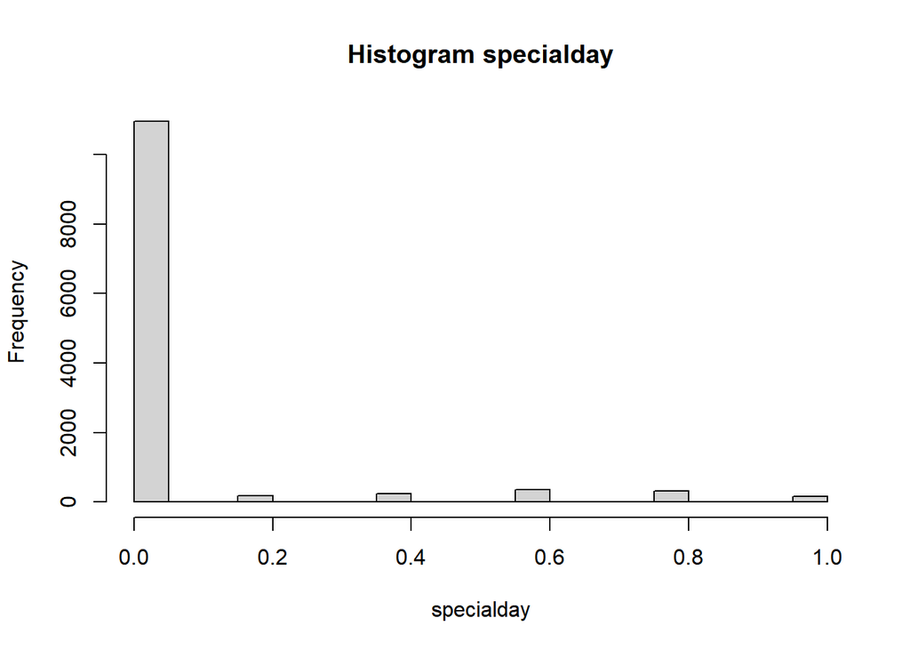

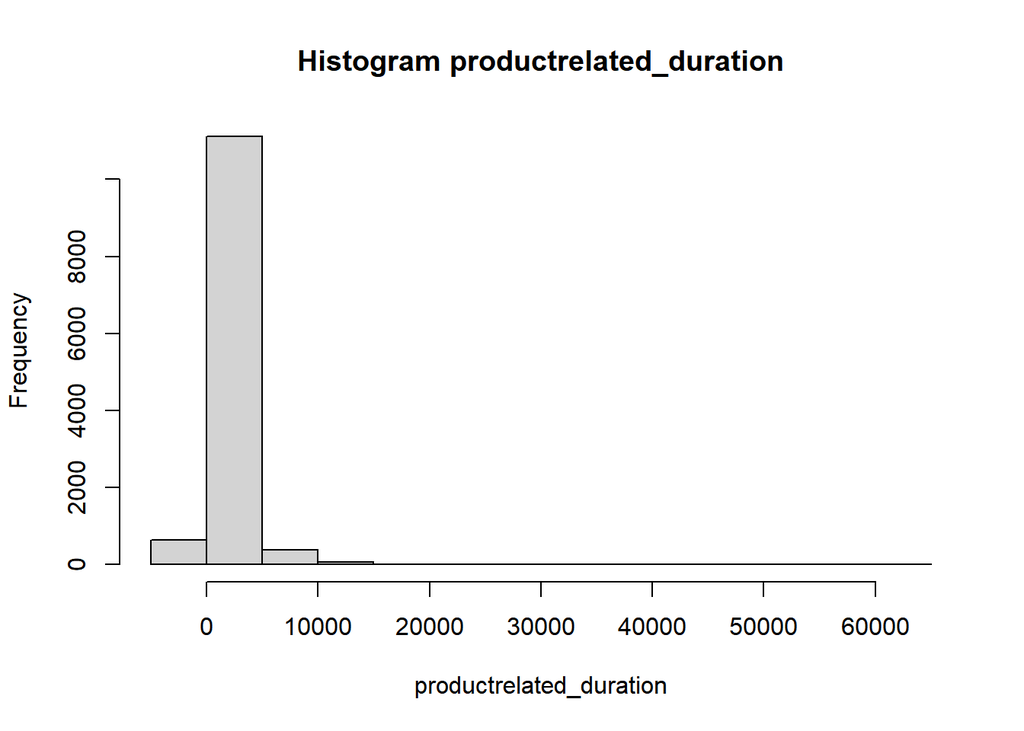

[output not shown]

[output cut: 207 more lines]

[output not shown]

```r
op <- par(mfrow=c(1,1))  # to put histograms side by side
lapply(seq(contvar), function(x)
  hist(x=contvar[[x]], xlab=names(contvar)[x], main=paste("Histogram",colnames(contvar[,..x]))))
```

```r
par(op)  # restore
```

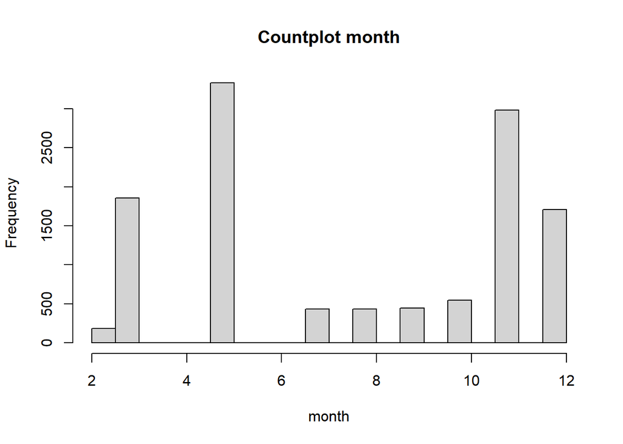

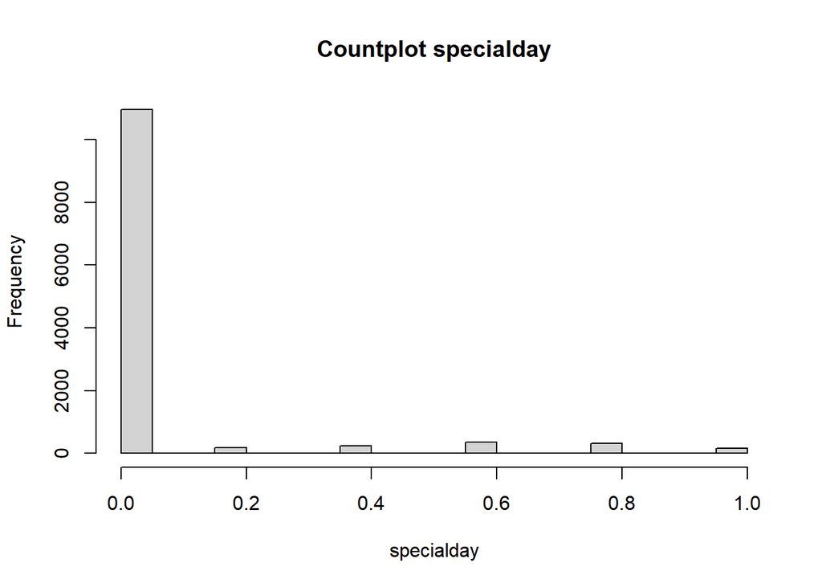

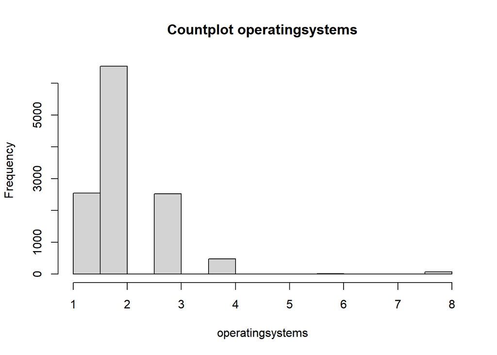

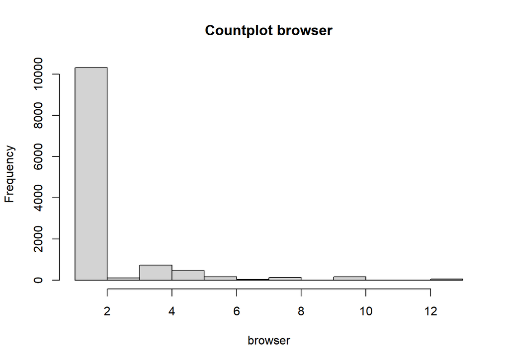

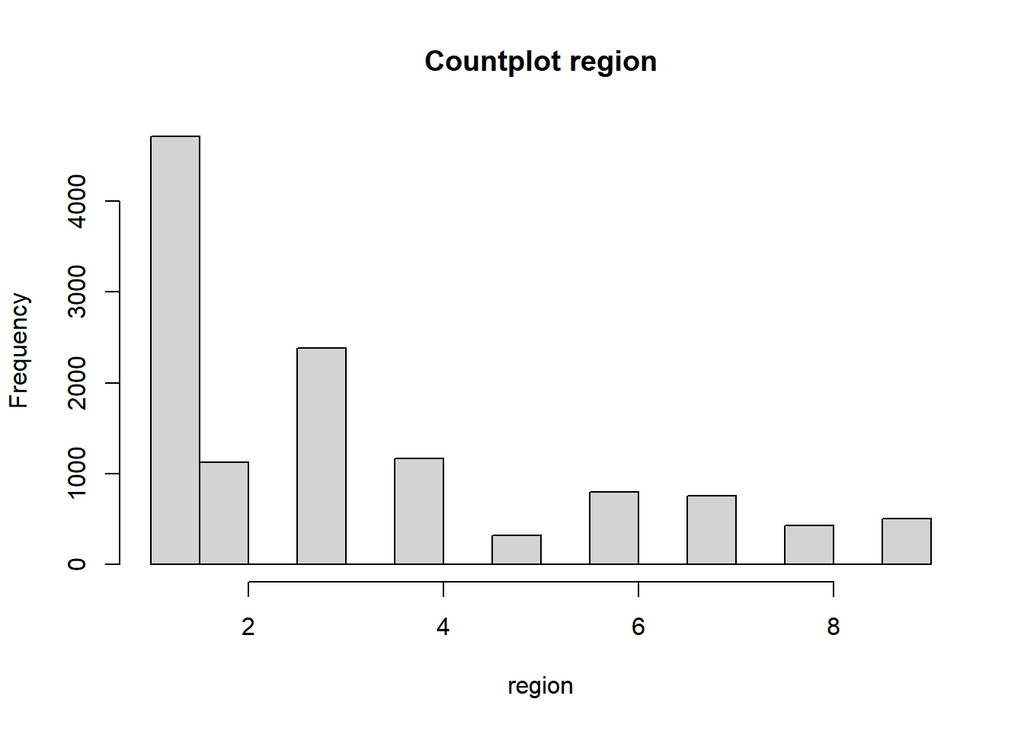

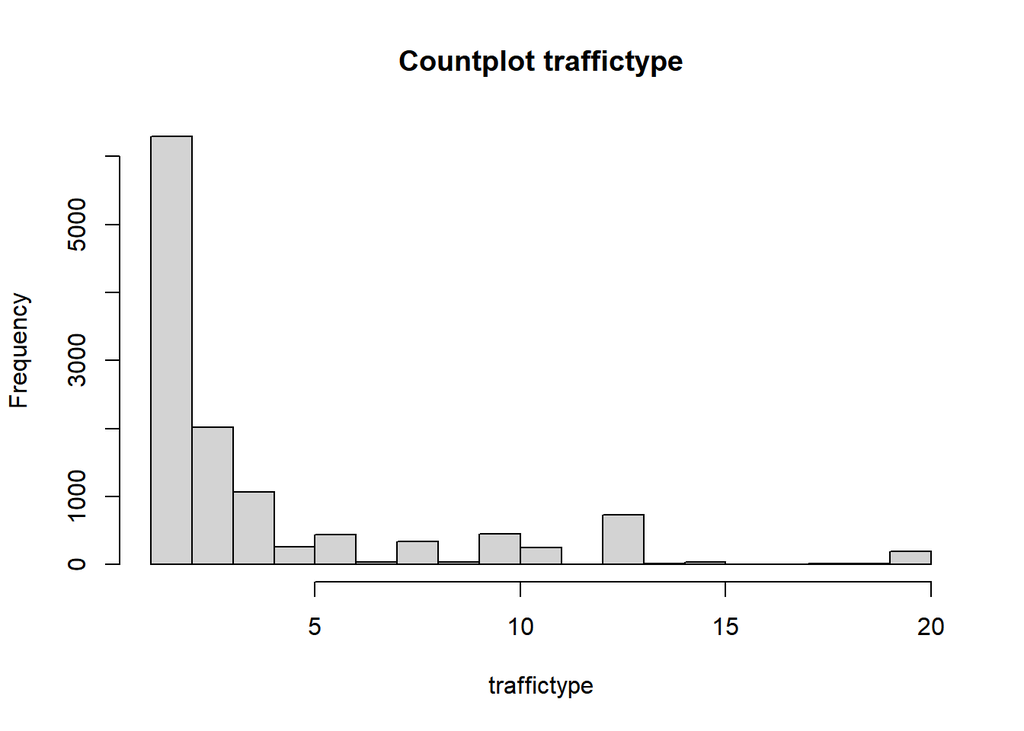

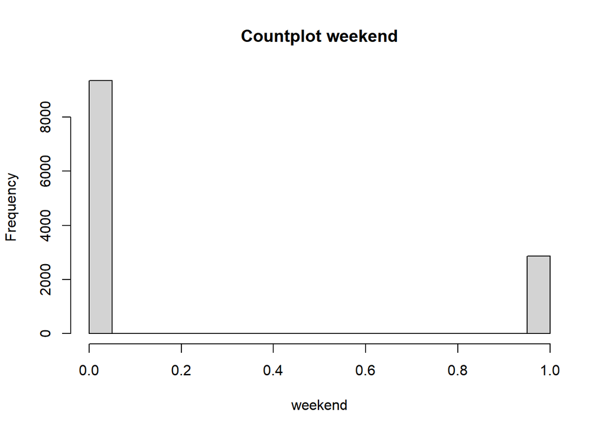

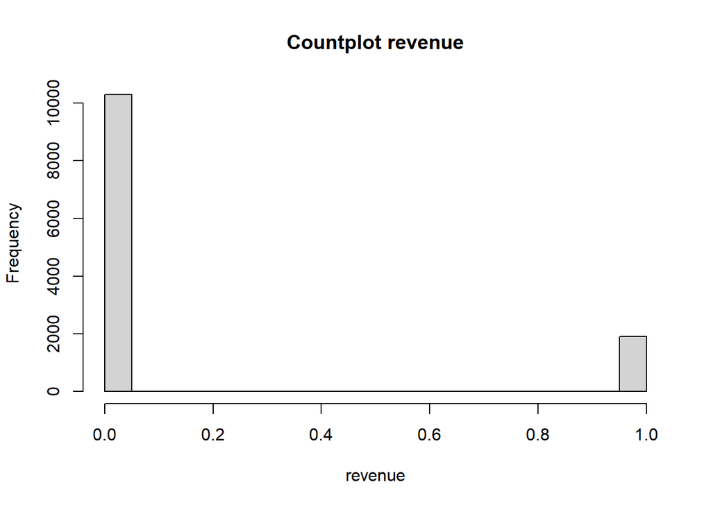

[output not shown]

[output cut: 155 more lines]

[output not shown]

```r
# Getting the numeric categorical variables
catvar <- df %>% select(month,specialday,operatingsystems,browser,region,traffictype,weekend,revenue,specialday)
op <- par(mfrow=c(1,1))  # to put histograms side by side
lapply(seq(catvar), function(x)
  hist(x=catvar[[x]], xlab=names(catvar)[x], main=paste("Countplot",colnames(catvar[,..x]))))
```

```r
par(op)
```

## BIVARIATE ANALYSIS

```r
str(df)
```

```
## Classes 'data.table' and 'data.frame':   12199 obs. of  18 variables:
##  $ administrative         : int  0 0 0 0 0 0 0 1 0 0 ...
##  $ administrative_duration: num  0 0 -1 0 0 0 -1 -1 0 0 ...
##  $ informational          : int  0 0 0 0 0 0 0 0 0 0 ...
##  $ informational_duration : num  0 0 -1 0 0 0 -1 -1 0 0 ...
##  $ productrelated         : int  1 2 1 2 10 19 1 1 2 3 ...
##  $ productrelated_duration: num  0 64 -1 2.67 627.5 ...
##  $ bouncerates            : num  0.2 0 0.2 0.05 0.02 ...
##  $ exitrates              : num  0.2 0.1 0.2 0.14 0.05 ...
##  $ pagevalues             : num  0 0 0 0 0 0 0 0 0 0 ...
##  $ specialday             : num  0 0 0 0 0 0 0.4 0 0.8 0.4 ...
##  $ month                  : int  2 2 2 2 2 2 2 2 2 2 ...
##  $ operatingsystems       : int  1 2 4 3 3 2 2 1 2 2 ...
##  $ browser                : int  1 2 1 2 3 2 4 2 2 4 ...
##  $ region                 : int  1 1 9 2 1 1 3 1 2 1 ...
##  $ traffictype            : int  1 2 3 4 4 3 3 5 3 2 ...
##  $ visitortype            : chr  "Returning_Visitor" "Returning_Visitor" "Returning_Visitor" "Returning_Visitor" ...
##  $ weekend                : int  0 0 0 0 1 0 0 1 0 0 ...
##  $ revenue                : int  0 0 0 0 0 0 0 0 0 0 ...
##  - attr(*, ".internal.selfref")=<externalptr>
```

```r
nums <- select_if(df, is.numeric)
cor(contvar)
```

```
##                         administrative administrative_duration informational
## administrative              1.00000000              0.60040965    0.37528761
## administrative_duration     0.60040965              1.00000000    0.30143630
## informational               0.37528761              0.30143630    1.00000000
## informational_duration      0.25478602              0.23718986    0.61867795
## productrelated              0.42819151              0.28678391    0.37260472
## bouncerates                -0.21366664             -0.13733340   -0.10950530
## exitrates                  -0.31127413             -0.20202445   -0.15956681
## pagevalues                  0.09692097              0.06616837    0.04739015
## specialday                 -0.09707210             -0.07473689   -0.04937677
## productrelated_duration     0.37102722              0.35351379    0.38608372
##                         informational_duration productrelated bouncerates
## administrative                      0.25478602     0.42819151 -0.21366664
## administrative_duration             0.23718986     0.28678391 -0.13733340
## informational                       0.61867795     0.37260472 -0.10950530
## informational_duration              1.00000000     0.27906195 -0.07015947
## productrelated                      0.27906195     1.00000000 -0.19351577
## bouncerates                        -0.07015947    -0.19351577  1.00000000
## exitrates                          -0.10293268    -0.28616321  0.90335819
## pagevalues                          0.03006416     0.05411549 -0.11599198
## specialday                         -0.03129304    -0.02593062  0.08783999
## productrelated_duration             0.34658069     0.86030819 -0.17437550
##                          exitrates  pagevalues  specialday
## administrative          -0.3112741  0.09692097 -0.09707210
## administrative_duration -0.2020245  0.06616837 -0.07473689
## informational           -0.1595668  0.04739015 -0.04937677
## informational_duration  -0.1029327  0.03006416 -0.03129304
## productrelated          -0.2861632  0.05411549 -0.02593062
## bouncerates              0.9033582 -0.11599198  0.08783999
## exitrates                1.0000000 -0.17357154  0.11678376
## pagevalues              -0.1735715  1.00000000 -0.06453271
## specialday               0.1167838 -0.06453271  1.00000000
## productrelated_duration -0.2453340  0.05084062 -0.03821065
##                         productrelated_duration
## administrative                       0.37102722
## administrative_duration              0.35351379
## informational                        0.38608372
## informational_duration               0.34658069
## productrelated                       0.86030819
## bouncerates                         -0.17437550
## exitrates                           -0.24533401
## pagevalues                           0.05084062
## specialday                          -0.03821065
## productrelated_duration              1.00000000
```

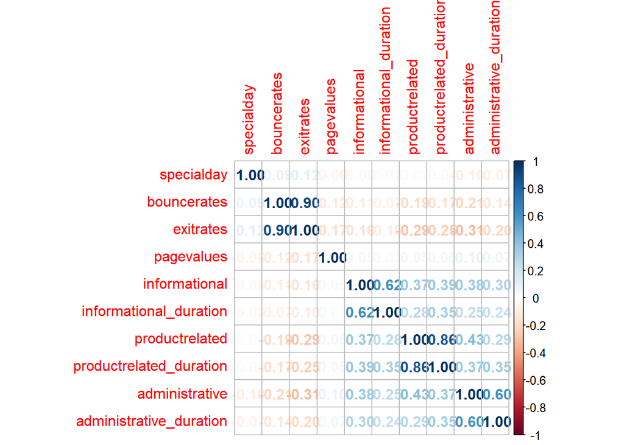

```r
library("corrplot")
par(mfrow=c(1,1))
corrplot(cor(contvar), method = "number", order = 'hclust')
```

* Exit rates and bounce rates are highly positively correlated * Information and information duration are highly positively correlated * Product and product duration are highly positively correlated * Product related is positively correlated with administrative * administrative and administrative duration are highly positively correlated

## FEATURE ENGINEERING

```r
# Convert visitor type to numerical
df$visitortype <- as.factor(df$visitortype) # convert to factor
df$visitortype <- as.numeric(df$visitortype) # convert to numeric

# Drop class column revenue for supervised learning
df_1 <- df[,-"revenue"]
head(df_1)
```

```
##    administrative administrative_duration informational informational_duration
## 1:              0                       0             0                      0
## 2:              0                       0             0                      0
## 3:              0                      -1             0                     -1
## 4:              0                       0             0                      0
## 5:              0                       0             0                      0
## 6:              0                       0             0                      0
##    productrelated productrelated_duration bouncerates exitrates pagevalues
## 1:              1                0.000000  0.20000000 0.2000000          0
## 2:              2               64.000000  0.00000000 0.1000000          0
## 3:              1               -1.000000  0.20000000 0.2000000          0
## 4:              2                2.666667  0.05000000 0.1400000          0
## 5:             10              627.500000  0.02000000 0.0500000          0
## 6:             19              154.216667  0.01578947 0.0245614          0
##    specialday month operatingsystems browser region traffictype visitortype
## 1:          0     2                1       1      1           1           3
## 2:          0     2                2       2      1           2           3
## 3:          0     2                4       1      9           3           3
## 4:          0     2                3       2      2           4           3
## 5:          0     2                3       3      1           4           3
## 6:          0     2                2       2      1           3           3
##    weekend
## 1:       0
## 2:       0
## 3:       0
## 4:       0
## 5:       1
## 6:       0
```

```r
# Normalise the columns
## set up the normalising function
normalize <- function(x){
  return ((x-min(x)) / (max(x)-min(x)))
}
## Normalise the columns
df.norm<- as.data.frame(lapply(df_1, normalize))
df.norm <- df.norm[,-11]
```

## UNSUPERVISED LEARNING

### K MEANS

```r
# Applying the K-means clustering algorithm with no. of centroids(k)=2
result<- kmeans(df.norm,2)
# Getting the cluster vector that shows the cluster where each record falls
result$cluster
```

[output not shown]

[output cut: 324 more lines]

```
##
##        0    1
##   1 8978 1470
##   2 1313  438
```

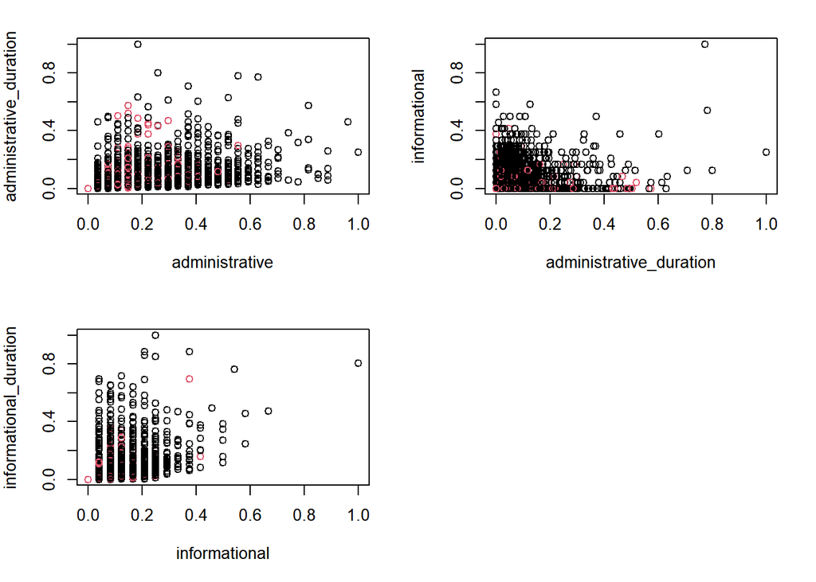

```r
# Verifying the results of clustering
par(mfrow = c(2,2), mar = c(5,4,2,2))
# Plotting to see how col1 and col2 data points have been distributed in clusters
plot(df.norm[c(1,2)], col = result$cluster)
# Plotting to see how col2 and col3 data points have been distributed in clusters
plot(df.norm[c(2,3)], col = result$cluster)
# Plotting to see how col3 and col4 points have been distributed in clusters
plot(df.norm[c(3,4)], col = result$cluster)

# Confusion matrix of clusters
table(result$cluster, df$revenue)
```

### Hierachical clustering

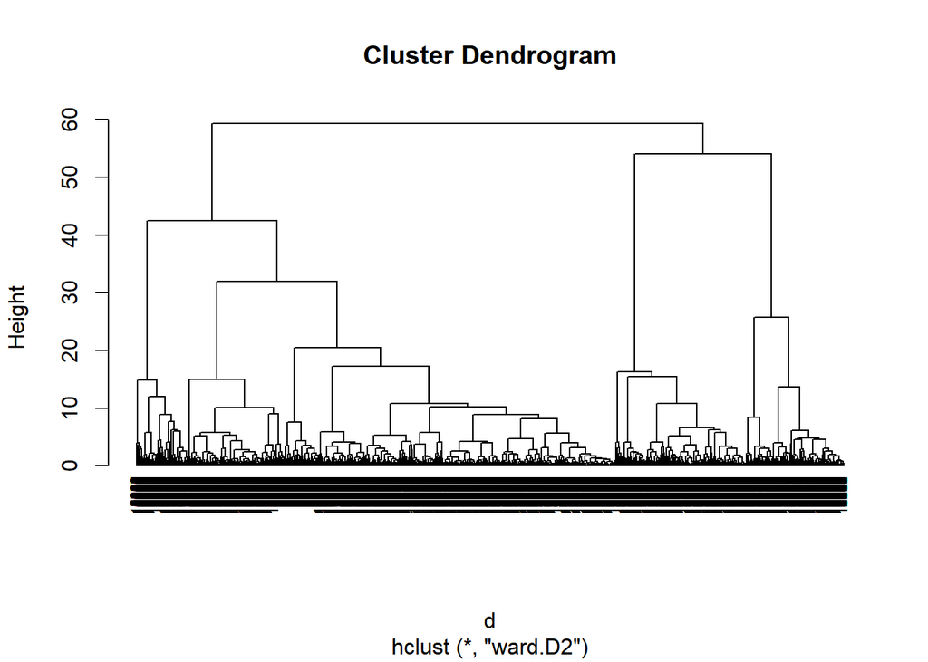

```r
# First we use the dist() function to compute the Euclidean distance between observations,
d <- dist(df.norm, method = "euclidean")
# We then hierarchical clustering using the Ward's method
res.hc <- hclust(d, method = "ward.D2" )
# Lastly, we plot the obtained dendrogram
plot(res.hc, cex = 0.6, hang = -1)
```

```r
# Split dendogram into clusters
cut_avg <- cutree(res.hc, k = 2)
# Create dataframe for results
df_cl <- mutate(df.norm, cluster = cut_avg)
count(df_cl,cluster)
```

```
##   cluster    n
## 1       1 8259
## 2       2 3940
```

```r
# Creating a confusion matrix for the result
table(df_cl$cluster, df$revenue)
```

```
##
##        0    1
##   1 7167 1092
##   2 3124  816
```

- Check on dimensionality reduction and removing correlated features to improve the model ## SUPERVISED LEARNING ### svm

```r
library(caret)
df_sup <- df.norm
df_sup$revenue <- df$revenue
# Next we split the data into training set and testing set.
intrain <- createDataPartition(y = df$revenue, p= 0.7, list = FALSE)
training <- df_sup[intrain,]
testing <- df_sup[-intrain,]
# COnverting the target variable to a factor
training[["revenue"]] = factor(training[["revenue"]])

# Modelling
trctrl <- trainControl(method = "repeatedcv", number = 10, repeats = 3)

svm_Linear <- train(revenue ~., data = training, method = "svmLinear",
trControl=trctrl,
preProcess = c("center", "scale"),
tuneLength = 10)
# Checking the results
svm_Linear
```

```
## Support Vector Machines with Linear Kernel
##
## 8540 samples
##   16 predictor
##    2 classes: '0', '1'
##
## Pre-processing: centered (16), scaled (16)
## Resampling: Cross-Validated (10 fold, repeated 3 times)
## Summary of sample sizes: 7686, 7686, 7686, 7686, 7686, 7686, ...
## Resampling results:
##
##   Accuracy   Kappa
##   0.8846604  0.4753265
##
## Tuning parameter 'C' was held constant at a value of 1
```

```r
# We can use the predict() method for predicting results as shown below.

test_pred <- predict(svm_Linear, newdata = testing)
test_pred
```

[output not shown]

[output cut: 85 more lines]

```r
# Now checking for our accuracy of our model by using a confusion matrix

confusionMatrix(table(test_pred, testing$revenue))
```

```
## Confusion Matrix and Statistics
##
##
## test_pred    0    1
##         0 3025  326
##         1   86  222
##
##                Accuracy : 0.8874
##                  95% CI : (0.8767, 0.8975)
##     No Information Rate : 0.8502
##     P-Value [Acc > NIR] : 3.7e-11
##
##                   Kappa : 0.4606
##
##  Mcnemar's Test P-Value : < 2e-16
##
##             Sensitivity : 0.9724
##             Specificity : 0.4051
##          Pos Pred Value : 0.9027
##          Neg Pred Value : 0.7208
##              Prevalence : 0.8502
##          Detection Rate : 0.8267
##    Detection Prevalence : 0.9158
##       Balanced Accuracy : 0.6887
##
##        'Positive' Class : 0
##
```

- Check on dimensionality reduction and removing correlated features to improve the model